# AE 18: Pokemon Inference

Suggested answers

Today we’ll explore the question “Are taller Pokémon speedier than shorter Pokémon?”

# Packages

```r
library(tidyverse)
library(tidymodels)
```

# Data

The data for this application exercise was originally gathered using the [**Complete Pokémon Dataset**](https://www.kaggle.com/datasets/rounakbanik/pokemon) from Kaggle.

First, let’s load the data:

```r
pokemon <- read_csv("data/pokemon.csv")
```

To keep things simple, we’ll work with a subset of the data, the generation 4 Pokémon.

```r
pokemon <- pokemon |>
  filter(generation == 4)

glimpse(pokemon)
```

```
Rows: 121
Columns: 17
$ name            <chr> "Turtwig", "Grotle", "Torterra", "Chimchar", "Monferno…
$ generation      <dbl> 4, 4, 4, 4, 4, 4, 4, 4, 4, 4, 4, 4, 4, 4, 4, 4, 4, 4, …
$ type_1          <chr> "Grass", "Grass", "Grass", "Fire", "Fire", "Fire", "Wa…
$ type_2          <chr> NA, NA, "Ground", NA, "Fighting", "Fighting", NA, NA, …
$ height_m        <dbl> 0.4, 1.1, 2.2, 0.5, 0.9, 1.2, 0.4, 0.8, 1.7, 0.3, 0.6,…
$ weight_kg       <dbl> 10.2, 97.0, 310.0, 6.2, 22.0, 55.0, 5.2, 23.0, 84.5, 2…
$ total_points    <dbl> 318, 405, 525, 309, 405, 534, 314, 405, 530, 245, 340,…
$ hp              <dbl> 55, 75, 95, 44, 64, 76, 53, 64, 84, 40, 55, 85, 59, 79…
$ attack          <dbl> 68, 89, 109, 58, 78, 104, 51, 66, 86, 55, 75, 120, 45,…
$ defense         <dbl> 64, 85, 105, 44, 52, 71, 53, 68, 88, 30, 50, 70, 40, 6…
$ sp_attack       <dbl> 45, 55, 75, 58, 78, 104, 61, 81, 111, 30, 40, 50, 35, …
$ sp_defense      <dbl> 55, 65, 85, 44, 52, 71, 56, 76, 101, 30, 40, 60, 40, 6…
$ speed           <dbl> 31, 36, 56, 61, 81, 108, 40, 50, 60, 60, 80, 100, 31, …
$ catch_rate      <dbl> 45, 45, 45, 45, 45, 45, 45, 45, 45, 255, 120, 45, 255,…
$ base_friendship <dbl> 70, 70, 70, 70, 70, 70, 70, 70, 70, 70, 70, 70, 70, 70…
$ base_experience <dbl> 64, 142, 236, 62, 142, 240, 63, 142, 239, 49, 119, 218…
$ is_legendary    <lgl> FALSE, FALSE, FALSE, FALSE, FALSE, FALSE, FALSE, FALSE…
```

We are interested in whether a Pokémon’s log height (measured in meters) can predict its speed (how fast it is).

# Visualize

1. Review! Create a new variable for the Pokémon’s log height.

```r
pokemon <- pokemon |>
  mutate(log_height = log(height_m))
```

2. **Your turn**: Plot the data and the line of best fit.

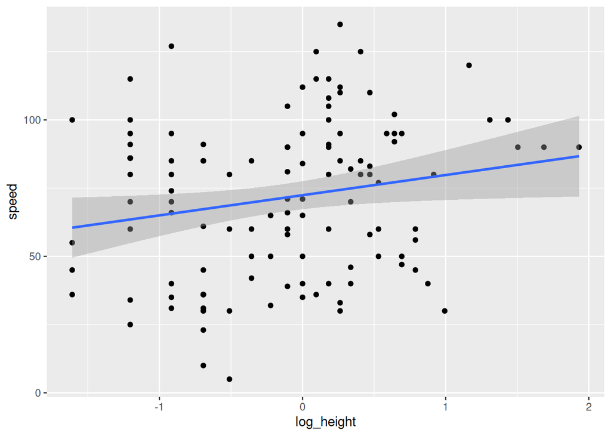

```r
ggplot(pokemon, aes(x = log_height, y = speed)) +
  geom_point() +
  geom_smooth(method = "lm")
```

# Point Estimation

1. **Your turn**: Fit the linear model to these data:

```r
observed_fit <- pokemon |>
  specify(speed ~ log_height) |>
  fit()
observed_fit
```

```
# A tibble: 2 × 2
  term       estimate
  <chr>         <dbl>
1 intercept     72.4
2 log_height     7.39
```

**Note**

This gives the exact same numbers that you get if you use `linear_reg() |> fit()`, but we need this new syntax because it plays nice with the tools we have for confidence intervals and hypothesis tests.

2. **Your turn**: Typeset the equation for the model fit:

$$\widehat{\text{speed}} = 72.41 + 7.39\times \log(\text{height})$$

3. **Your turn**: Interpret the slope and the intercept estimates:
   - If a Pokémon had 0 log(height) (equivalently 1 m tall), we predict that it would have a 72.41 speed stat on average.
   - A 1 unit increase in log(height) is associated with a 7.39 increase in speed, on average.

# Hypothesis Testing

Let’s consider the hypotheses:

$$H_0:\beta_1=0\quad vs\quad H_A: \beta_1\neq 0.$$

The null hypothesis corresponds to the claim that log_height and speed are uncorrelated.

1. Simulate and plot the null distribution for the slope:

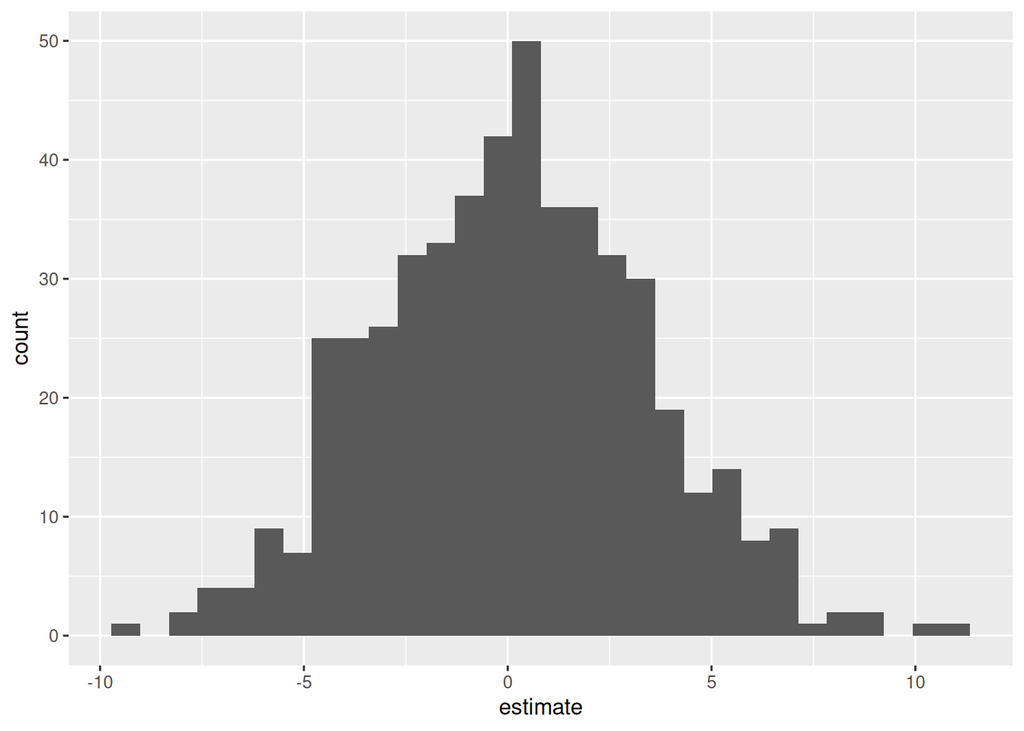

```r
set.seed(24601)
null_dist <- pokemon |>
  specify(speed ~ log_height) |>
  hypothesize(null = "independence") |>
  generate(reps = 500, type = "permute") |>
  fit()

null_dist |>
  filter(term == "log_height") |>
  ggplot(aes(x = estimate)) +
  geom_histogram()
```

2. Add a vertical line to your plot indicating the point estimate of the slope from your original data analysis:

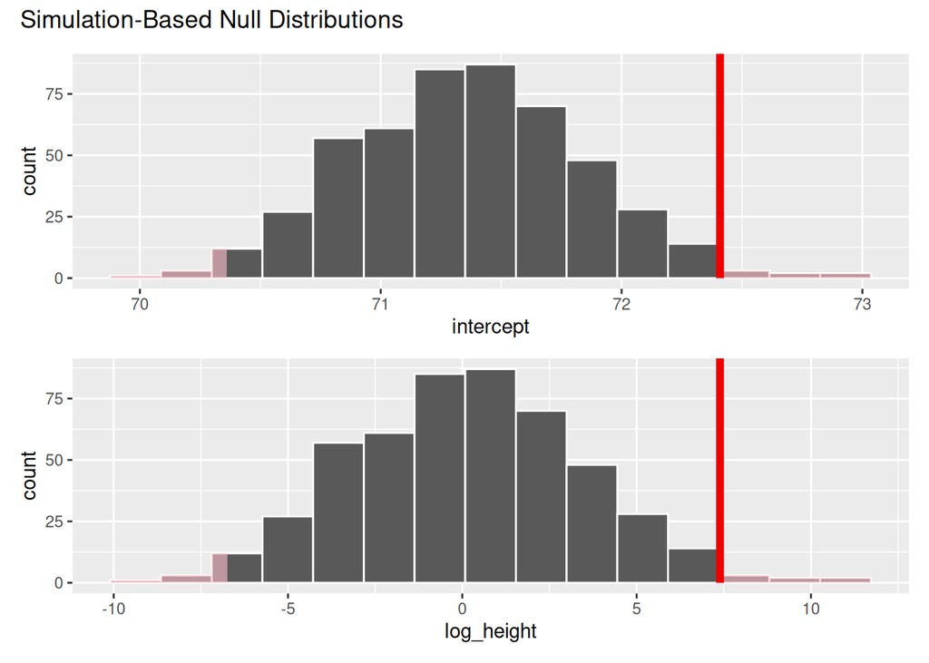

```r
visualize(null_dist) +
  shade_p_value(obs_stat = observed_fit, direction = "two-sided")
```

3. Compute the $p$-value for this test and interpret it:

```r
null_dist |>
  get_p_value(obs_stat = observed_fit, direction = "two-sided")
```

```
# A tibble: 2 × 2
  term       p_value
  <chr>        <dbl>
1 intercept    0.028
2 log_height   0.028
```

**Answer**: If the null were true and $\beta_1=0$ (meaning log_height and speed are uncorrelated), the probability of getting an estimate as or more extreme than the one we got ($b_1=7.39$) is 0.028. So we reject the null hypothesis. Evidence is sufficient to conclude that $\beta_1$, whatever it is, is not equal to zero.

# Interval Estimation

1. **Demo**: Using seed `24601`, generate `500` bootstrap samples, and store them in a new data frame called `bstrap_samples`.

```r
set.seed(24601)
bstrap_samples <- pokemon |>
  specify(speed ~ log_height) |>
  generate(reps = 500, type = "bootstrap")
```

2. **Demo**: Fit a linear model to each of these bootstrap samples and store the estimates in a new data frame called `bstrap_fits`.

```r
bstrap_fits <- bstrap_samples |>
  fit()
```

3. **Your turn**: Use `linear_reg() |> fit(...)` to fit a linear model to bootstrap sample number *347*, and verify that you get the same estimates as the ones contained in `bstrap_fits`.

```r
replicate_347 <- bstrap_samples |>
  filter(replicate == 347)

linear_reg() |>
  fit(speed ~ log_height, data = replicate_347) |>
  tidy()
```

```
# A tibble: 2 × 5
  term        estimate std.error statistic  p.value
  <chr>          <dbl>     <dbl>     <dbl>    <dbl>
1 (Intercept)    71.6       2.61     27.4  2.64e-53
2 log_height      6.46      3.09      2.09 3.84e- 2
```

```r
bstrap_fits |>
  filter(replicate == 347)
```

```
# A tibble: 2 × 3
# Groups:   replicate [1]
  replicate term       estimate
      <int> <chr>         <dbl>
1       347 intercept     71.6
2       347 log_height     6.46
```

**Note**

The only point I’m making here is that this new bootstrap code is not performing a fundamentally new task. It’s performing an old task (fitting the linear model), but it’s repeating it A LOT.

4. **Demo**: Compute 95% confidence intervals for the slope and the intercept using the `get_confidence_interval` command.

```r
ci_95 <- get_confidence_interval(
  bstrap_fits,
  point_estimate = observed_fit,
  level = 0.95,
  type = "percentile"
)
ci_95
```

```
# A tibble: 2 × 3
  term       lower_ci upper_ci
  <chr>         <dbl>    <dbl>
1 intercept    67.4       76.6
2 log_height    0.942     13.3
```

5. **Your turn**: Verify that you get the same numbers when you manually calculate the quantiles of the slope estimates using `summarize` and `quantile`. *Pay attention to the grouping*.

```r
bstrap_fits |>
  ungroup() |>
  group_by(term) |>
  summarize(
    lower_ci = quantile(estimate, 0.025),
    upper_ci = quantile(estimate, 0.975)
  )
```

```
# A tibble: 2 × 3
  term       lower_ci upper_ci
  <chr>         <dbl>    <dbl>
1 intercept    67.4       76.6
2 log_height    0.942     13.3
```

**Note**

Same point as before. There’s no magic here. `get_confidence_interval` is just a convenient way of doing something that you already knew how to do.

6. **BONUS**: You can visualize the confidence interval:

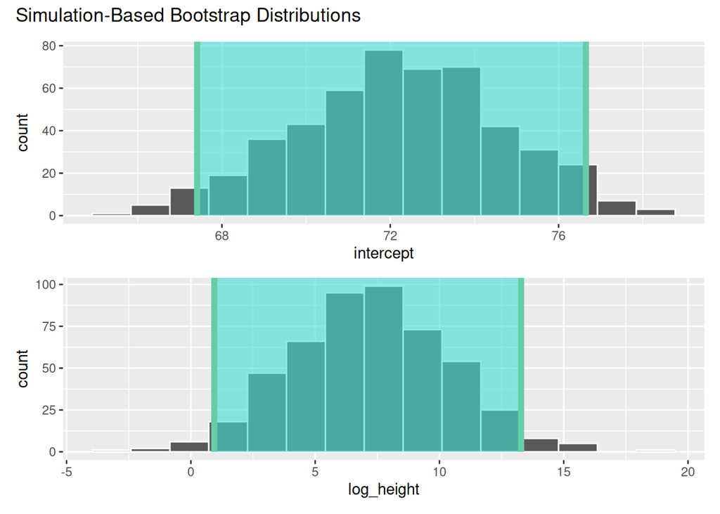

```r
visualize(bstrap_fits) +
  shade_confidence_interval(ci_95)
```